# Castone Project I - Geo-Mapping Yelp Businesses & Predict Rank Stars

## Project Goals

When someone wants to move to some place to live, or travel to some city, or have a long vacation to explore more places, they usually have some questions such as "Where to go?", "How's the place?","What's funny in this area?", etc.. People can use yelp, google, or tourist guides to find some restaurants, sceneries.

But the information they searched most probably is about a specific spot. How about an area, for example, within 25 square miles? This area has many museums and souvenir stores, that place has many Cafe and restaurants, another place has many gyms, hotels, and rental apartments. If people can make a sketch or even a portrait for places, they can make better plans for saving money and saving time.

This project will statistically extract business information, using the data set offered by the Yelp company, covering 7 USA states and 354 cities, and 127189 businesses which are grouped into nine business category groups such as catering, fitness, shopping, etc., showing all statistical information on a three layers dynamic map.

This project also will prove that there is a strong positive relationship between the number of reviews and the number of review votes.

At last, we will predict businesses stars ranked by users from their reviews.

## Data Source

The data set comes from the [Yelp's Open Dataset](https://www.yelp.com/dataset). The documentation of the data set is [here](https://www.yelp.com/dataset/documentation/json).

The Yelp dataset offered is a subset of businesses, reviews, and user data for use in personal, educational, and academic purposes. There are 5,200,000 reviews, 174,000 businesses, and 200,000 pictures, covering 11 metropolitan areas.

## Data Cleaning

The Yelp data set contains five JSON files which are "business.json", "review.json", "checkin.json", "tip.json", "user.json" and "photos.json". This project will focus on the data on businesses and reviews.

### Tidy data on seven states in USA

There 174567 observations in the business dataframe, each observation represents a business entity such as a restaurant or a fitness club. Those businesses are located in 68 states or provinces in the USA and other countries. Here we just need states of USA. In addition, the number of businesses should be big enough to portray a place. So we choose states in the USA which has more than 1000 businesses in our data set. Then we will have a new data set containing 127189 businesses in seven USA states whose abbreviations are: 'AZ','IL','NC','NV','OH','PA' and 'WI'.

### Businesses grouped into nine category groups

In the data set, the 'categories' variable of a business is defined with a random way. Each business has its own content of the 'categories'. For a good overview on all businesses, we separate all businesses into 9 category groups which are: 'Entertainment & Catering', 'Nearby Services','House-inside Services','Fitness, Health Care', 'Shopping', 'Education', 'Auto, Transportation', 'Public Facilities', 'Other Professional Service'. 'Nearby Services' includes the routing services people need such as hair saloon, pet care, bank, post, etc., 'House-inside Services' include all serviced people need for their house such as plumbing, cleaning, repairing etc.. We combine fitness and medical health care together, and combine car services with transportation facilities such as airport, bus station.

Grouping businesses is a quite complicated task, and can be grouped by different view angle. It's important to describe a place. Actually, there is much more job to do on this issue far beyond what we have done in this project.

### ZIP code and City name corrected via the Google Geocoding API

There are lots of missing values or error values in the contents of variables, like 'address', 'postal_code', 'city', 'neighborhood'. The 'address' has 5974 missing values, the 'neighborhood' has 89680 missing values, and the 'postal_code' has 410 missing values.

Considering the [Google Geocoding API Usage Limits](https://developers.google.com/maps/documentation/geocoding/usage-limits), we choose to fill the missing values of the 'postal_code'.

We also need to get the right values of the 'city', '110 Las Vegas' definitely is not a right city name. If we want to do statistics on the state level, and the city level, we need right cities' names.

We cannot correct all cities' names with iterating each observation. After filling the missing values of the 'postal_code', we can group observations by 'state', 'postal_code' and 'city', and get one set of 'latitude' and 'longitude', representing the location coordinates of each city, to inquire the city name from Google Geocoding API. Thus the number of requests will below the 2500 limitation.

### Add on review-votes correlated with reviews in the business dataframe

There are near 5,200,000 reviews in the 'reviews.json'. It's too large for our project. We extract variables related to review votes, which are 'useful', 'funny', 'cool', and merge them with the business dataframe. Thus we have a cleaned dataframe containing major businesses' location information like 'state', 'city', 'postal_code', 'latitude' and 'longitude'. We also have some social measurement information for each business like 'review_count' and three kinds of review votes('useful', 'cool' and 'funny').

### Split 5 million reviews' text into a small data set for predicting ranking stars

Five million observations for classification in this project is too big. So we split it three times using Scikit-learn's 'train-test-split', and finally get a small data set with reasonable size of near 100K observations. We will split the data set again to create our training and test data sets, and use them to predict Yelp business ranking stars using Multinomial Naive Bayes methods and Logistic Regression methods.

## Mapping Statistics

### Statistics for states and cities

We make statistics for businesses on state-level and city-level.

For state-level, we count the number of all businesses for each state; sum 'review_count','review_votes','useful' and 'funny'; and calculate the average stars for each state. We also do same thing for each business category group in each state.

We also do similar statistics for all cities like what we have done for all states

```python
print("\033[1m"+"- Statistics of businesses in seven states")
stats_1
```

```
- Statistics of businesses in seven states
```

|  | state | review_count | review_votes | useful | funny | cool | business_count | avg_stars |
| --- | --- | --- | --- | --- | --- | --- | --- | --- |
| 0 | AZ | 1626599 | 3965302 | 2298110 | 778284 | 888907 | 52033 | 3.73 |
| 1 | IL | 36354 | 83897 | 54729 | 15952 | 13216 | 1847 | 3.49 |
| 2 | NC | 307241 | 594562 | 357185 | 113261 | 124116 | 12920 | 3.58 |
| 3 | NV | 1823791 | 4997199 | 2627722 | 1090966 | 1278511 | 32986 | 3.72 |
| 4 | OH | 243502 | 539333 | 312736 | 111577 | 115020 | 12568 | 3.55 |
| 5 | PA | 229725 | 552262 | 311440 | 100414 | 140408 | 10091 | 3.61 |
| 6 | WI | 109694 | 243452 | 148733 | 40998 | 53721 | 4744 | 3.64 |

```python
print("\033[1m"+"- Statistics of businesses of nine category groups in seven states")
stats_2[0:9]
```

```
- Statistics of businesses of nine category groups in seven states
```

|  | state | cat_groups | review_count | review_votes | useful | funny | cool | business_count | avg_stars |
| --- | --- | --- | --- | --- | --- | --- | --- | --- | --- |
| 2 | AZ | Entertainment & Catering | 1053252 | 2435910 | 1266770 | 530276 | 638863 | 15208 | 3.50 |
| 5 | AZ | Nearby Services | 155252 | 334655 | 228248 | 48899 | 57508 | 8506 | 4.04 |
| 4 | AZ | House-inside Services | 116699 | 303424 | 212454 | 45076 | 45894 | 7793 | 3.83 |
| 3 | AZ | Fitness,Health Care | 93477 | 280003 | 191928 | 45119 | 42956 | 6949 | 3.88 |
| 0 | AZ | Auto,Transportation | 96532 | 226652 | 157156 | 37266 | 32230 | 4738 | 3.74 |
| 6 | AZ | Other Professional Service | 44175 | 157075 | 113949 | 21986 | 21140 | 4344 | 3.64 |
| 8 | AZ | Shopping | 49843 | 156664 | 86563 | 34833 | 35268 | 3435 | 3.61 |
| 1 | AZ | Education | 6044 | 27889 | 18536 | 4876 | 4477 | 607 | 4.08 |
| 7 | AZ | Public Facilities | 11325 | 43030 | 22506 | 9953 | 10571 | 453 | 3.37 |

```python
print("\033[1m"+"- Statistics of businesses in each city of each state")
stats_3.head()
```

```
- Statistics of businesses in each city of each state
```

|  | state | city | review_count | review_votes | business_count | avg_stars |
| --- | --- | --- | --- | --- | --- | --- |
| 0 | AZ | Apache Junction | 23 | 78 | 2 | 3.50 |
| 1 | AZ | Avondale | 16581 | 34255 | 622 | 3.45 |
| 2 | AZ | Buckeye | 45 | 63 | 3 | 4.83 |
| 3 | AZ | Carefree | 1957 | 4013 | 84 | 3.92 |
| 4 | AZ | Cave Creek | 10087 | 17254 | 380 | 3.99 |

```python
print("\033[1m"+"- Statistics of businesses of nine category groups in each city of each state")
stats_4[0:10]
```

```
- Statistics of businesses of nine category groups in each city of each state
```

|  | state | city | cat_groups | review_count | review_votes | business_count | avg_stars |
| --- | --- | --- | --- | --- | --- | --- | --- |
| 0 | AZ | Apache Junction | Auto,Transportation | 23 | 78 | 2 | 3.50 |
| 3 | AZ | Avondale | Entertainment & Catering | 10469 | 20606 | 220 | 3.40 |
| 6 | AZ | Avondale | Nearby Services | 1489 | 2715 | 104 | 3.70 |
| 1 | AZ | Avondale | Auto,Transportation | 1814 | 4818 | 73 | 3.39 |
| 4 | AZ | Avondale | Fitness,Health Care | 869 | 1800 | 69 | 3.49 |
| 5 | AZ | Avondale | House-inside Services | 907 | 1801 | 62 | 3.53 |
| 9 | AZ | Avondale | Shopping | 548 | 1062 | 44 | 3.38 |
| 7 | AZ | Avondale | Other Professional Service | 287 | 810 | 36 | 3.17 |
| 8 | AZ | Avondale | Public Facilities | 152 | 477 | 9 | 3.22 |
| 2 | AZ | Avondale | Education | 46 | 166 | 5 | 3.10 |

### Statistical Mapping

After doing statistics for all states and all cities, we can mapping these statistics.

On the map of states, We will show three icons representing top three business groups in each state. Clicking on any icon will pop up an information window showing general statistics of the state and its top three business groups.

Using the drop down menu, we can choose a state to show a new map with all cities' statistics in the state. We will show 2 to 5 icons representing the top 2 - top 5 business groups in each city. The number of icons depends on how many cities in the state, more cities less icons, vice versa.

At last, we can choose a city in a state to show a map with up to 200 businesses in the descending order by the value of each business' total reviews. The reason choosing the number of reviews because it's a important metric measuring the social activities on each business. Later we will do hypothesis test for the relationship between the number of reviews and the number of review votes.

The slideshow cannot properly display the interactive menu. Click the "Click to Refresh Map" button on the next slide, we still can have a look on statistical information for the seven states. If you have an interest on the full Geo-mapping, you can run this notebook with "data" directory on a Jupyter notebook server.

```python
%%HTML
<html>
<head>
    <script>
        function show() {
            document.getElementById('mapHtml').src = 'data/maps/yelp.html';
        }
    </script>
</head>
<body>
    <button onclick="show()">Click to Refresh Map</button>
    <hr>
      <iframe id="mapHtml" width="100%" height="800" src="data/maps/usa.html"></iframe>
    </hr>
</body>
</html>
```

[interactive chart not shown]

## Graphical Data Exploration

### The portion of each business category group

We first make a plot of businesses' frequencies with nine category groups.

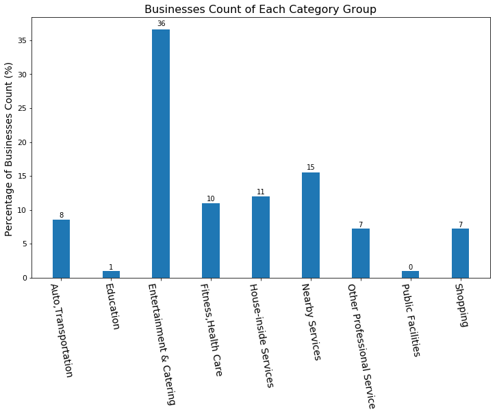

```python
business_count1 = business.groupby(['cat_groups'])['business_id'].count().reset_index()
business_count1 = business_count1.rename(columns={'business_id':'business_count'})
plt.figure(figsize=(12,7))
plt_1 = plt.bar(business_count1.cat_groups,business_count1.business_count*100/business_count1.business_count.sum(),width=0.35)
ax = plt.gca()
autolabel(plt_1,ax)
plt.xticks(rotation=280,size=14)
plt.yticks(size=11)
plt.ylabel("Percentage of Businesses Count (%) ",size=14)
plt.title("Businesses Count of Each Category Group",size=16)
plt.show()
```

On this plot, we can find that, in the nine category groups, **'Entertainment & Catering'** has the biggest number of businesses, which is about 36% of total number of all businesses. The next one is **'Nearby Services'** which has 15% businesses. **'House-inside Services'** and **'Fitness,Health Care'** are 11% and 10%.

These four groups are the major business fields of the Yelpers' activities, and they own **72%** businesses.

### The portion of business category groups in each state

Next, we can make a plot of businesses' frequencies in different category group and in different state.

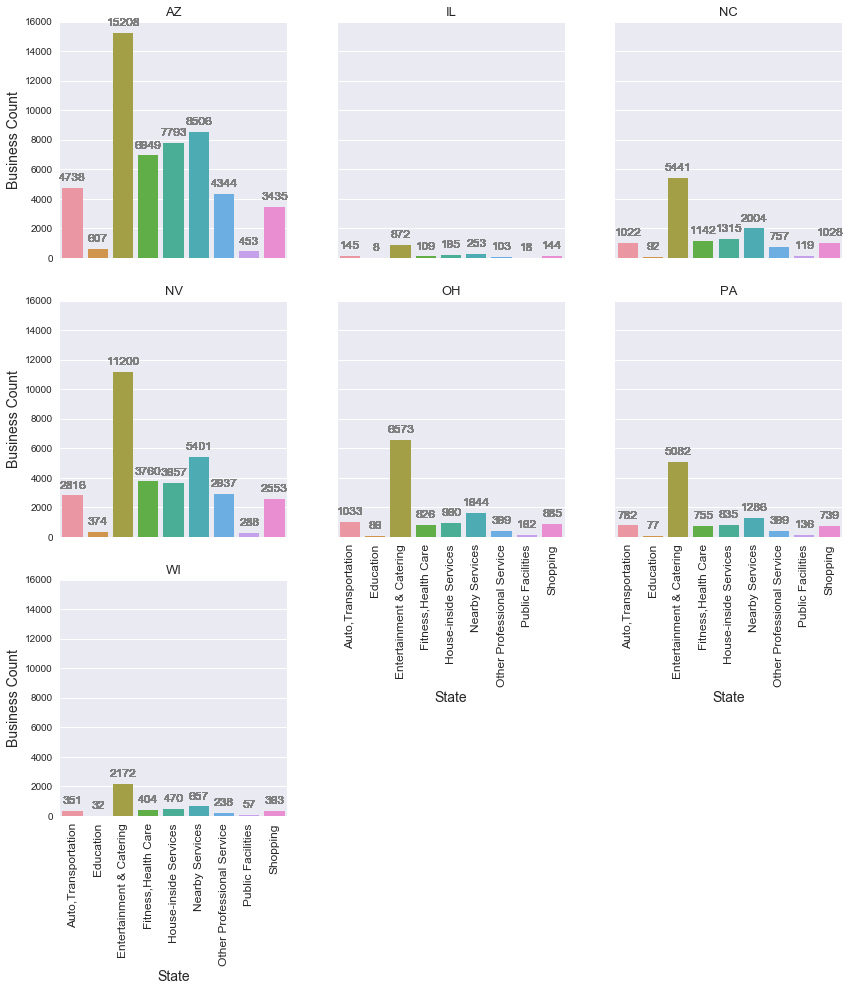

```python
business_count2 = business.groupby(['cat_groups','state'])['business_id'].count().reset_index()
business_count2 = business_count2.rename(columns={'business_id':'business_count'})
colors = ["magenta","windows blue", "amber", "greyish", "faded green", "dusty purple","chocolate"]
pal = sns.xkcd_palette(colors)
sns.set()
plt_2 = sns.factorplot(x='cat_groups',y='business_count',col='state',kind='bar',col_wrap=3,legend=True,data=business_count2)
ax = plt.gca()
(plt_2.set_xlabels("State",size=14)
     .set_ylabels("Business Count",size=14)
     .set_xticklabels(size=12,rotation=90)
    .set_titles("{col_name}",size=13)
    .despine(left=True))

for ax in plt_2.axes.flatten():
    business_count2.apply(annotateBars, ax=ax, axis=1)

plt.show()
```

In the current data set, Arizona and Nevada nearly have half or more of businesses comparing to other five states. This may be the reason that the Yelp company doesn't offer full data observations for each state. For example, there are no any data from Philadelphia PA.

But we still can do statistics for cities offered in this data set.

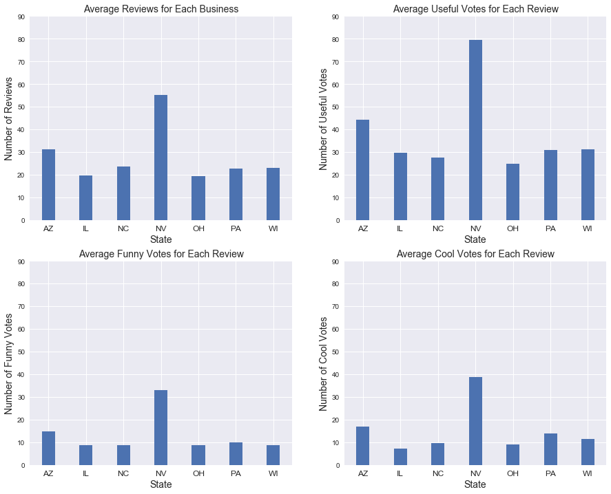

```python
plt.figure(figsize=(15,12))
plt.tight_layout()

plt.subplot(221)
plt_3_1 = plt.bar(stats_1.state,stats_1['review_count']/stats_1['business_count'],width=0.35)
plt.xticks(size=12)
plt.title("Average Reviews for Each Business",size=14)
plt.xlabel("State",size=14)
plt.ylabel("Number of Reviews",size=14)
plt.ylim(ymax=90,ymin=0)

plt.subplot(222)
plt_3_2 = plt.bar(stats_1.state,stats_1['useful']/stats_1['business_count'],width=0.35)
plt.xticks(size=12)
plt.title("Average Useful Votes for Each Review",size=14)
plt.xlabel("State",size=14)
plt.ylabel("Number of Useful Votes",size=14)
plt.ylim(ymax=90,ymin=0)

plt.subplot(223)
plt_3_3 = plt.bar(stats_1.state,stats_1['funny']/stats_1['business_count'],width=0.35)
plt.xticks(size=12)
plt.title("Average Funny Votes for Each Review",size=14)
plt.xlabel("State",size=14)
plt.ylabel("Number of Funny Votes",size=14)
plt.ylim(ymax=90,ymin=0)


plt.subplot(224)
plt_3_4 = plt.bar(stats_1.state,stats_1['cool']/stats_1['business_count'],width=0.35)
plt.xticks(size=12)
plt.title("Average Cool Votes for Each Review",size=14)
plt.xlabel("State",size=14)
plt.ylabel("Number of Cool Votes",size=14)
plt.ylim(ymax=90,ymin=0)
plt.show()
```

*Nevada obviously is the most active state on Yelp.*

## Hypothesis Test for Linear Relationship

### Linear Plots

We have mapped statistics on state-level, city-level and business-level. Now we will make plots for the relationship between 'review_count' and 'review_votes'.

We can plot this relationship separated by business category groups.

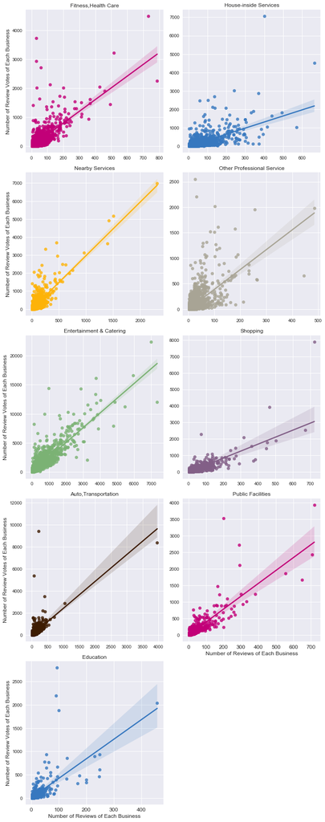

```python
plt_5 = sns.lmplot(x="review_count", y="review_votes",hue="cat_groups",sharex=False, sharey=False,
           col="cat_groups", col_wrap=2,size=5, palette=pal,scatter_kws={'alpha':0.8},truncate=True,data=business);
(plt_5.set_xlabels("Number of Reviews of Each Business",size=12)
     .set_ylabels("Number of Review Votes of Each Business",size=12)
     .set_titles("{col_name}",size=12)
     .set_xticklabels(size=12))

plt.show()
```

### Hypothesis Test

#### Null Hypothesis

The number of reivews and the number of review votes are completely uncorrelated.

#### Pearson Correlation Coefficient Statistic and Bootstrap method

We will use the Pearson Correlation Coefficient as the statistic to do the hypothesis test.

At First we will calculate the Pearson Correlation Coefficient with current samples in the business dataframe.

```python
corrcoef_reviews_votes = pearson_cc(review_count,review_votes)
print("Pearson Correlation Coefficient of Observed: ", corrcoef_reviews_votes)
```

```
Pearson Correlation Coefficient of Observed:  0.8922885763465185
```

The Pearson Correlation Coefficient of sample data is near 0.89, this means there may be a strong positive relationship between the two variables.

Then under the null hypothesis, we will use bootstrap method to simulate 10000 times experiments choosing randomly values of 'review_count' and 'review_votes'.

```
- Pearson Correlation Coefficient in 10000 Bootstrap Experiments
```

```
<function matplotlib.pyplot.show>
```

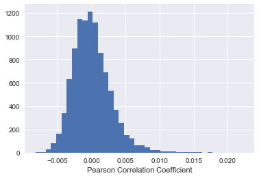

```python
print("\033[1m"+"- Pearson Correlation Coefficient in 10000 Bootstrap Experiments")
_ = plt.hist(bs_replicates_corrcoef,bins=40)
plt.xlabel('Pearson Correlation Coefficient')
plt.show
```

We calculate the probability that the statistic of bootstrap data is at least as extrem as the statistic of observed sample data, which is the p-value. The result of calculation is below:

```python
p = np.sum(bs_replicates_corrcoef >= corrcoef_reviews_votes)/len(bs_replicates_corrcoef)
print("p-value:", p)
```

```
p-value: 0.0
```

#### Conclution of the hypothesis test

The result of p-vlaue is zero,actually it is too small and close to zero. This means the null hypothesis is rejected, and **there is a strong positive relationship between the number of reviews and the number of review votes.**

Considering this relationship, if we want to choose those two features to do prediction, we can just pick one of them.

A good thing is, when doing recommendation system, we can find strong connection, from the users who wrote reviews, to those who voted the reviews.

## Predict Ranking Stars From Reviews

### Reading data splitted from whole reviews data set

Read review text file into 'reviews' dataframe which will be used as $X$ data array.

```python
reviews.head()
```

|  | text |
| --- | --- |
| 4857008 | Not much remarkable can be said about BBB as a... |
| 1548549 | Margs, Guac, Tacos...all amazing! I like my Ma... |
| 4987279 | Visited OooWee while at Triple C this weekend.... |
| 4904860 | I am here visiting my sister in AZ. She has be... |
| 822535 | This one star is only towards one of the I am ... |

```python
reviews.shape
```

```
(105233, 1)
```

Read stars file as stars dataframe which will be use as $y$ data array.

```python
stars.head()
```

|  | stars |
| --- | --- |
| 4857008 | 3 |
| 1548549 | 5 |
| 4987279 | 3 |
| 4904860 | 2 |
| 822535 | 1 |

```python
stars.shape
```

```
(105233, 1)
```

### Using scikit-learn's CountVectorizer and MultinomialNB models with default parameters

We use CountVectorizer with default parameters to transform the reviews' text contents into sparse matrix, and then use the *tocsc* function to convert the sparse matrix into the Compressed Sparse Column format, which will be used as the X input for MultinomialNB model. We use values of the 'stars' column as the y input.

Then we use the *train_test_split* function to split X and y into X_train, y_train, X_test and y_test data, with test_size as 0.25.

We create a classifier by MultinomialNB function with default parameters, which means we do nothing on tuning hyperparameters. Then we use X_train, y_train to fit the model, and use the model's predict function with the X_test data to do predict. At last, we print out the model's accuracies on training data and test data.

```python
clf = MultinomialNB()
clf.fit(X_train,y_train)
clf.predict(X_test)
print("Accuracy on training data: {:2f}".format(clf.score(X_train,y_train)))
print("Accuracy on test data:     {:2f}".format(clf.score(X_test,y_test)))
```

```
Accuracy on training data: 0.670607
Accuracy on test data:     0.592155
```

### Tuning hyperparameters of models

#### The 'min_df' parameter of CountVectorizer

With the performance of the initial model, we can firstly tuning the cutoff parameter of CountVectorizer, which is 'min_df'.

We construct a cumulative distribution of document frequencies (df). The $x$-axis is a document count $x_i$ and the $y$-axis is the number of words that appear less than $x_i$ times. For example, at $x=5$, the point representing the number of words that appear in 5 or fewer documents. Look for the point at which the curve begins climbing steeply. This may be a good value for `min_df`.

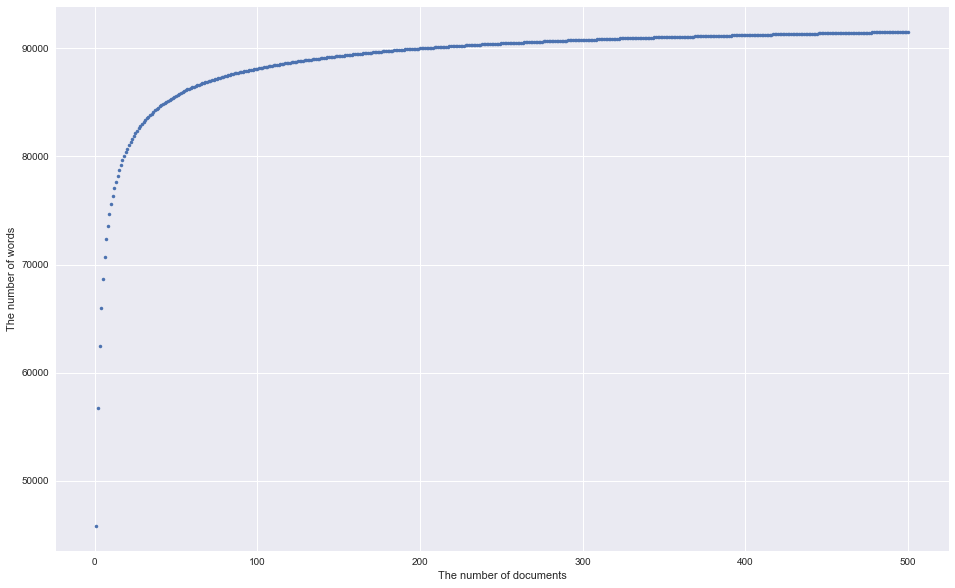

```python
doc_num = []
words_num = []
words_appear = (X>0).astype(np.int).sum(axis=0)
for i in range(500):
    count = (words_appear <= (i+1)).astype(np.int).sum()
    words_num.append(count)
    doc_num.append(i+1)
_ = plt.figure(figsize=(16,10))
_ = plt.plot(np.asarray(doc_num),np.asarray(words_num),marker='.',linestyle='none')
_ = plt.xlabel('The number of documents')
_ = plt.ylabel('The number of words')
plt.show()
```

From the plot above, we can see that $2$ is a good choice for the value of the `min_df`.

#### The 'ngram_range' parameter of CountVectorizer and the 'alpha' parameter of MultinomialNB

Next, we will use *GridSearchCV* function to tune the `ngram_range` parameter of *CountVectorizer*, and the `alpha` parameter of *MultinomialNB* together.

Considering the big computation cost of *GridSearchCV*, we will split 'reviews' and 'stars' into a dataset with near 10000 observations.

We will use a pipeline, a parameter grid as the input of *GridSearchCV*, and define the value of `cv` parameter equals 5 which means *GridSearchCV* will implement 5-fold cross-validation.

The pipeline includes two steps which are *CountVectorizer* and *MultinomialNB*. The parameter grid is a dictionary with parameter names as keys and lists of parameter settings to try as values, those parameters correspond the two models in the pipeline.

We will use the fit method of *GridSearchCV* with the dataset splitted previously, and then get the best model score and best parameters via the attributes of *GridSearchCV*, which are `best_score_` and `best_params_`.

```python
pipeline = make_pipeline(CountVectorizer(),MultinomialNB())
param_grid = {
    "multinomialnb__alpha": [.1,1,5,10],
    "countvectorizer__ngram_range": [(1,1),(1,2),(1,5)]
}

grid = GridSearchCV(pipeline,param_grid,cv=5)
grid.fit(X2_train,y2_train)
print("Best score: {:.2f}".format(grid.best_score_))
print("Best Parameter:\n{}".format(grid.best_params_))
```

```
Best score: 0.59
Best Parameter:
{'countvectorizer__ngram_range': (1, 5), 'multinomialnb__alpha': 0.1}
```

The result of *GridSearchCV* shows that best `ngram_range` for *CountVectorizer* is (1,5), actually sometimes the result also shows (1,2) is the best; And for *MultinomiaNB* classifier, the best `alpha` value is 0.1; With those two tuned parameters, the *MultinomialNB* classifier gets the best accuracy score of 0.59.

#### Using KFold and cross_val_score with a cheaper computation cost

The computation cost of *GridSearchCV* is quite expensive. We can use *KFold* function and *cross_val_score* function to tune parameters of a model. This time we will tune the `alpha` for *MultinomialNB*, and we will use `F1_score` as the metric measuring the performance of the model with different `alpha` values.

```python
alphas = [.1, 1, 5, 10, 50]
best_alpha = None
maxscore=-np.inf
seed = 2014

for alpha in alphas:
    kfold = KFold(n_splits=5, random_state=seed)
    model = MultinomialNB(alpha=alpha)
    scoring = 'f1_weighted'
    #scoring = 'accuracy'
    #scoring = 'neg_log_loss'

    results = cross_val_score(model, X_train, y_train, cv=kfold, scoring=scoring)
    score = results.mean()
    print("alpha: {}".format(alpha))
    print("{} score: {}".format(scoring,score))
    if score > maxscore:
        maxscore = score
        best_alpha = alpha
```

```
alpha: 0.1
f1_weighted score: 0.5804927167020888
alpha: 1
f1_weighted score: 0.578258700013272
alpha: 5
f1_weighted score: 0.5049048713405406
alpha: 10
f1_weighted score: 0.41317705229697815
alpha: 50
f1_weighted score: 0.2631426348322682
```

```python
print("Best alpha: {}".format(best_alpha))
print("Best F1 score: {}".format(maxscore))
```

```
Best alpha: 0.1
Best F1 score: 0.5804927167020888
```

The tuning result also shows that the best `alpha` value is 0.1.

#### Train and Test the Classifier with the tuned parameters on the full data set

Now, we will use those three tuned parameters, `min_df = 2`, `ngram_range = (1,5)` for *CountVectorizer*, and `alpha = 0.1` for *MultinomialNB*, to create a new set of $X$ features via the whole data set which has more than 100K observations, and use it to get the training data and the test data. Then we train a new *MultinomialNB* classifier on the training data, and predict labels on the test data. At last, we print out the score of this new classifier.

```python
clf = MultinomialNB(alpha=0.1)
clf.fit(X_train,y_train)
predictedlabel = clf.predict(X_test)
print("Accuracy on training data: {:2f}".format(clf.score(X_train,y_train)))
print("Accuracy on test data:     {:2f}".format(clf.score(X_test,y_test)))
```

```
Accuracy on training data: 0.988964
Accuracy on test data:     0.618838
```

The new classifier gets near 0.99 accuracy on the training data, and gets near 0.62 accuracy on the test data. It gets a big improvement with a 0.32 higher accuracy on the training data, whereas a 0.03 higher accuracy of the test data, comparable to the classifier without tuning, which has a 0.67 accuracy of the training data, and a 0.59 accuracy of the test data.

```python
print ("Classification report: \n", classification_report(y_test, predictedlabel))
print ("F1 micro averaging:",f1_score(y_test, predictedlabel, average='micro'))
```

```
Classification report:
              precision    recall  f1-score   support

          1       0.69      0.72      0.71      3662
          2       0.37      0.41      0.39      2166
          3       0.42      0.42      0.42      3164
          4       0.49      0.57      0.53      6208
          5       0.82      0.71      0.76     11109

avg / total       0.64      0.62      0.63     26309

F1 micro averaging: 0.61883766011631
```

From the classification report, we can see that the classifier can predict 1 star and 5 star much better than other stars. It means that predicting the best and the worst, or predicting positive and negative is more practicable than the stratifying meaning of documents.

### Comparison with LogisticRegression classifier

There is another classic classifier worth trying, which is *LogisticRegression*.

Use the same method we have done before, we firstly use *make_pipeline* and *GridSearchCV* to tune the `ngram_range` of *CountVectorizer*, and the `C` parameter of *LogisticRegression*, with the smaller data set with near 10K observations.

```python
pipeline2 = make_pipeline(CountVectorizer(),LogisticRegression())
param_grid2 = {
    "logisticregression__C": [0.001,0.1,1.0,10.0],
    "countvectorizer__ngram_range": [(1,1),(1,2),(1,5)]
}

grid2 = GridSearchCV(pipeline2,param_grid2,cv=5)
grid2.fit(X2_train,y2_train)
print("Best score: {:.2f}".format(grid2.best_score_))
print("Best Parameter:\n{}".format(grid2.best_params_))
```

```
Best score: 0.62
Best Parameter:
{'countvectorizer__ngram_range': (1, 5), 'logisticregression__C': 0.1}
```

Via *GridSearchCV*, the *LogisticRegression* classifier gets a best score of 0.62, with the corresponding `ngram_range = (1,5)` and `C = 0.1`. It has a score, which is 0.03 higher than the MultinomialNB classifier.

The computation cost of *GridSearchCV* with *LogisticRegression* is more than 5 times higher than the cost with *MultinomialNB*.

Let's check the performance of a new *LogisticRegression* classifier trained on the whole data set, with the two tuned parameters, and see if it worth consuming much more computation cost.

```python
vectorizer_lg = CountVectorizer(min_df=2,ngram_range=(1,5))
Xlg = vectorizer_lg.fit_transform(reviews.text.values)
Xlg = Xlg.tocsc()
Xlg_train, Xlg_test, ylg_train, ylg_test = train_test_split(Xlg, y, test_size=0.25)
clf_lg = LogisticRegression(C=0.1)
clf_lg.fit(Xlg_train,ylg_train)
predictedlabel_lg = clf_lg.predict(Xlg_test)
print("Accuracy on training data: {:2f}".format(clf_lg.score(Xlg_train,ylg_train)))
print("Accuracy on test data:     {:2f}".format(clf_lg.score(Xlg_test,ylg_test)))
```

```
Accuracy on training data: 0.989851
Accuracy on test data:     0.659318
```

```python
print ("Classification report: \n", classification_report(ylg_test, predictedlabel_lg))
print ("F1 micro averaging:",f1_score(ylg_test, predictedlabel_lg, average='micro'))
```

```
Classification report:
              precision    recall  f1-score   support

          1       0.75      0.81      0.78      3707
          2       0.49      0.27      0.35      2219
          3       0.49      0.37      0.42      3089
          4       0.52      0.47      0.49      6115
          5       0.74      0.87      0.80     11179

avg / total       0.64      0.66      0.64     26309

F1 micro averaging: 0.6593181040708502
```

The new *LogisticRegression* classifier gets a near 0.99 accuracy on training data, and gets a 0.66 accuracy of test data. It's accuracy of the test data is 0.04 higher than that of the *MultinomialNB* classifier.

## Discussion and further work

### Mapping Data as Dynamic Application

In this project, we dynamically do Geo-mapping 127,189 businesses in Yelp, grouped by their business categories, displaying business information for a whole state, or for a city, or for an individual business.

There is a limitation that we can run this map exchanging data with pandas in a dynamic Jupyter notebook. But we cannot do this in a static report with html or pdf format.

This is a trying for applying data science to dynamic application. Data science as an app, or as a platform, may be a good front-end service for massive normal users, not just a tool running in back-end used by organization or companies. Obviously, there is a lot of work to implement it. But, why not?

### Text Analysis Classification

#### Cost-effective VS Higher-performance

The *LogisticRegression* may be a better choice than *MultinomialNB* with rich and high-performance computing resources. On the other hand, the *MultinomialNB* is good for quick analysis and is much more cost-effective.

#### Preprocessing X features

We tuned `min_df` and `ngram_range` of *CountVectorizer* on extracting X features. In fact, `stop_words=english` of CountVectorizer is used in this project without getting any improvement on model performance. We also used Scikit-learn's *TfidfVectorizer* replacing *CountVectorizer*, and got worse performance.

We can do more on preprocessing, but now, all of the preprocessing jobs we have done are based on words distribution, we may consider if there are better practical methods of preprocessing, which can help extracting more specific documents' meaning. Meaningful extraction can be a good foundation to improve recommendation system.